# R Tutorial at the WZB

November 29, 2018

## Today's schedule

1. Review of last weeks' tasks and recap
2. Data aggregation and summarization

## Review of last weeks' tasks and recap

## Solutions and review of previous tasks

Solutions for all previous tasks are online at https://wzbsocialsciencecenter.github.io/wzb_r_tutorial/

**Any problems, questions?**

## Recap

I prepared a small quiz for you…

## Transforming data with R II

## What we've learned so far

We already got to know several *dplyr "verbs"* for transforming data:

- `filter()` for filtering (subsetting) rows (observations) according to some criteria
- `distinct()` for selecting only *unique* rows
- `arrange()` for ordering rows
- `select()` for selecting only certain columns (variables)
- `rename()` for giving new names to columns
- `mutate()` and `transmute()` for adding new columns

Today: Combining several verbs in one step and learning new verbs for **grouping and summarizing data**.

## Combining several dplyr verbs

Applying several steps is cumbersome this way:

```r
air_june <- filter(airquality, Month == 6)
air_june <- select(air_june, -Month)   # we don't need Month any more
head(air_june)
```

```
##   Ozone Solar.R Wind Temp Day
## 1    NA     286  8.6   78   1
## 2    NA     287  9.7   74   2
## 3    NA     242 16.1   67   3
## 4    NA     186  9.2   84   4
## 5    NA     220  8.6   85   5
## 6    NA     264 14.3   79   6
```

You can always nest functions:

```r
air_june <- select(filter(airquality, Month == 6), -Month)
```

→ makes code harder to read (you have to read "inside-out")

## Combining several dplyr verbs

A common approach to chain several data transformation steps is to use the **pipe operator:**

`step_one() %>% step_two() %>% ... %>% last_step()`

→ the output of one function is passed as input to the next function

```r
air_june <- filter(airquality, Month == 6) %>% select(-Month)
```

**Notice how `select()` has only one parameter, since it implicitely operates on the output of `filter()`.**

For long complex data transformations, each step is usually written on a separate line:

```r
air_june <- airquality %>%
  filter(Month == 6) %>%
  select(-Month) %>%
  arrange(desc(Wind))
```

## Aggregates with `group_by()` and `summarise()`

`summarise()` can be used to create summary statistics on aggregate data:

```r
summarise(airquality, mean_ozone = mean(Ozone, na.rm = TRUE))
```

```
##   mean_ozone
## 1   42.12931
```

→ summary of the whole data frame

## Aggregates with `group_by()` and `summarise()`

It is more useful in combination with `group_by()`, which forms groups based on the variables you pass:

```r
group_by(airquality, Month) %>% summarise(mean_ozone = mean(Ozone, na.rm = TRUE))
```

```
## # A tibble: 5 x 2
##   Month mean_ozone
##   <int>      <dbl>
## 1     5       23.6
## 2     6       29.4
## 3     7       59.1
## 4     8       60.0
## 5     9       31.4
```

→ summary per group, i.e. per month

## Aggregates with `group_by()` and `summarise()`

You can pass several aggregate values as arguments:

```r
group_by(airquality, Month) %>%
  summarise(mean_ozone = mean(Ozone, na.rm = TRUE),
            sd_ozone = sd(Ozone, na.rm = TRUE),
            n = n(),                        # number of obs. per group
            n_nonNA = sum(!is.na(Ozone)))   # number of non-NA Ozone obs.
```

```
## # A tibble: 5 x 5
##   Month mean_ozone sd_ozone     n n_nonNA
##   <int>      <dbl>    <dbl> <int>   <int>
## 1     5       23.6     22.2    31      26
## 2     6       29.4     18.2    30       9
## 3     7       59.1     31.6    31      26
## 4     8       60.0     39.7    31      26
## 5     9       31.4     24.1    30      29
```

- any function passed to `summarize` will operate on each group's observations
- `n()` counts the number of observations in each group

## Some more complex examples with the `flights` data

We'll use a subset `fl_sub` for some more grouping and summarizing examples.

```r
library(nycflights13)

fl_sub <- select(flights, origin, dest, distance, arr_delay)
head(fl_sub)
```

```
## # A tibble: 6 x 4
##   origin dest  distance arr_delay
##   <chr>  <chr>    <dbl>     <dbl>
## 1 EWR    IAH       1400        11
## 2 LGA    IAH       1416        20
## 3 JFK    MIA       1089        33
## 4 JFK    BQN       1576       -18
## 5 LGA    ATL        762       -25
## 6 EWR    ORD        719        12
```

- `origin` and `dest` are the origin and destination airports
- `distance` is the flight distance in miles
- `arr_delay` is the arrival delay in minutes

## Relationship between the distance and average delay

We want to find out what's the **relationship between distance and average delay per destination airport**. We want to **exclude small destination airports (<= 20 connections) and outlier Honolulu**. Which data transformation steps are necessary?

1. Group flights by destination with `group_by()`.
2. For each group, compute average distance, average delay and number of flights with `summarise()`.
3. Exclude observations according to mentioned criteria with `filter()`.

## Relationship between the distance and average delay

We want to find out what's the **relationship between distance and average delay per destination airport**. We want to **exclude small destination airports (<= 20 connections) and outlier Honolulu**.

```r
delays <- fl_sub %>%
  group_by(dest) %>%      # step 1
  summarise(count = n(),  # step 2
            mean_dist = mean(distance, na.rm = TRUE),
            mean_delay = mean(arr_delay, na.rm = TRUE)) %>%
  filter(count > 20, dest != "HNL")  # step 3
head(delays)
```

```
## # A tibble: 6 x 4
##   dest  count mean_dist mean_delay
##   <chr> <int>     <dbl>      <dbl>
## 1 ABQ     254     1826        4.38
## 2 ACK     265      199        4.85
## 3 ALB     439      143       14.4
## 4 ATL   17215      757.      11.3
## 5 AUS    2439     1514.       6.02
## 6 AVL     275      584.       8.00
```

## Relationship between the distance and average delay

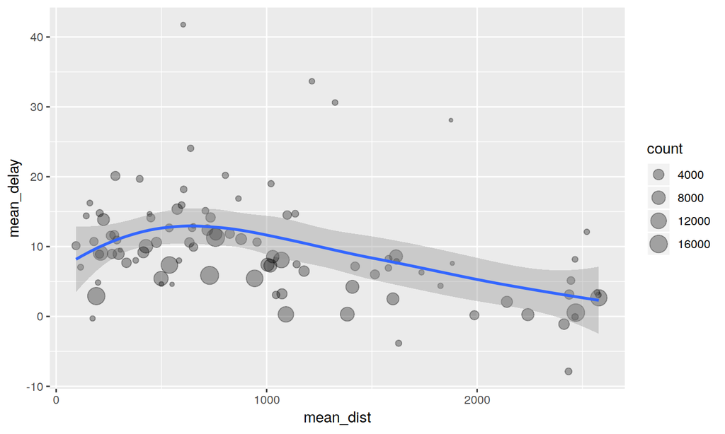

## Grouping by multiple variables

We want to know what the **most popular flight connections** are, and also which connections have the **lowest or highest average delays**. We will **exclude rarely used connections with less than 100 flights**. Which data transformation steps are necessary?

1. Group by `origin` *and* `dest` to form groups of connections.
2. Summarise by counting the number of observations per connection and computing the mean delay.
3. Exclude observations according to mentioned criteria with `filter()`.

## Grouping by multiple variables

We want to know what the **most popular flight connections** are, and also which connections have the **lowest or highest average delays**. We will **exclude rarely used connections with less than 100 flights**. Which data transformation steps are necessary?

```r
connections <- fl_sub %>%
  group_by(origin, dest) %>%   # step 1
  summarise(n = n(),           # step 2
            mean_delay = mean(arr_delay, na.rm = TRUE)) %>%
  filter(n >= 100)             # step 3
head(connections)
```

```
## # A tibble: 6 x 4
## # Groups:   origin [1]
##   origin dest      n mean_delay
##   <chr>  <chr> <int>      <dbl>
## 1 EWR    ALB     439     14.4
## 2 EWR    ATL    5022     13.2
## 3 EWR    AUS     968     -0.474
## 4 EWR    AVL     265      8.80
## 5 EWR    BDL     443      7.05
## 6 EWR    BNA    2336     12.7
```

## Grouping by multiple variables

Now we can obtain the top three connections by using `arrange()` and `head()`:

```r
connections %>% arrange(desc(n)) %>% head(3)
```

```
## # A tibble: 3 x 4
## # Groups:   origin [2]
##   origin dest      n mean_delay
##   <chr>  <chr> <int>      <dbl>
## 1 JFK    LAX   11262     -0.481
## 2 LGA    ATL   10263     11.3
## 3 LGA    ORD    8857      1.83
```

Or the top three connections with the least delay time:

```r
connections %>% arrange(mean_delay) %>% head(3)
```

```
## # A tibble: 3 x 4
## # Groups:   origin [2]
##   origin dest      n mean_delay
##   <chr>  <chr> <int>      <dbl>
## 1 EWR    SNA     825      -7.87
## 2 JFK    HNL     342      -6.92
## 3 JFK    STT     333      -6.37
```

## Grouping by multiple variables

Or the top three connections with the most delay time:

```r
connections %>% arrange(desc(mean_delay)) %>% head(3)
```

```
## # A tibble: 3 x 4
## # Groups:   origin [1]
##   origin dest      n mean_delay
##   <chr>  <chr> <int>      <dbl>
## 1 EWR    CAE     104       44.6
## 2 EWR    TYS     323       41.2
## 3 EWR    TUL     315       33.7
```

## Ungrouping

Once you group a data frame and assign it to an object, the grouping information is retained. You can see this in the additional information that is printed above the data (`Groups: ...`):

```r
head(connections)
```

```
## # A tibble: 6 x 4
## # Groups:   origin [1]
##   origin dest      n mean_delay
##   <chr>  <chr> <int>      <dbl>
## 1 EWR    ALB     439     14.4
## 2 EWR    ATL    5022     13.2
## 3 EWR    AUS     968     -0.474
## 4 EWR    AVL     265      8.80
## 5 EWR    BDL     443      7.05
## 6 EWR    BNA    2336     12.7
```

## Ungrouping

As long as a data frame is grouped, `summarise()` operates on the groups and not on the whole data frame:

```r
connections %>% summarise(median_n_conn = median(n))
```

```
## # A tibble: 3 x 2
##   origin median_n_conn
##   <chr>          <dbl>
## 1 EWR            1080.
## 2 JFK            1130.
## 3 LGA             761
```

You can remove the grouping information via `ungroup()`. Now `summarise()` operates on the whole data frame:

```r
connections %>% ungroup() %>% summarise(median_n_conn = median(n))
```

```
## # A tibble: 1 x 1
##   median_n_conn
##           <int>
## 1           997
```

## Tasks

## Tasks

See dedicated tasks sheet on the [tutorial website](https://wzbsocialsciencecenter.github.io/wzb_r_tutorial/).